# Context:

# Treating Outliers

```python
def treat_outliers(df,col):

    Q1=df[col].quantile(0.25)
    Q3=df[col].quantile(0.75)
    IQR=Q3-Q1
    Lower_Whisker = Q1 - 1.5*IQR
    Upper_Whisker = Q3 + 1.5*IQR
    df[col] = np.clip(df[col], Lower_Whisker, Upper_Whisker)

    return df

def treat_outliers_all(df, col_list):

    for c in col_list:
        df = treat_outliers(df,c)

    return df
```

```python
numerical_col = {'Avg_Credit_Limit','Total_visits_online'}
df = treat_outliers_all(df,numerical_col)
```

```python
((df.select_dtypes(include=['int64'])<lower) | (df.select_dtypes(include=['int64'])>upper)).sum()/len(data)*100
```

```
Avg_Credit_Limit       0.0
Total_Credit_Cards     0.0
Total_calls_made       0.0
Total_visits_bank      0.0
Total_visits_online    0.0
dtype: float64
```

### We have treated the outliers present for the columns Avg_Credit_Limit and Total_visits_online

### Scaling the Data Set

```python
scaler=StandardScaler()
subset=df.copy()
subset_scaled=scaler.fit_transform(subset)
```

```python
subset_scaled_df=pd.DataFrame(subset_scaled,columns=subset.columns)
```

### K-Means Clustering & Elbow Curve

```
Number of Clusters: 1 	Average Distortion: 2.0731463576129583
Number of Clusters: 2 	Average Distortion: 1.4986141501796377
Number of Clusters: 3 	Average Distortion: 1.1823298853410935
Number of Clusters: 4 	Average Distortion: 1.0711026440504199
Number of Clusters: 5 	Average Distortion: 1.0049644472109056
Number of Clusters: 6 	Average Distortion: 0.9521602744807107
Number of Clusters: 7 	Average Distortion: 0.9148279474885657
Number of Clusters: 8 	Average Distortion: 0.8904872995101861
```

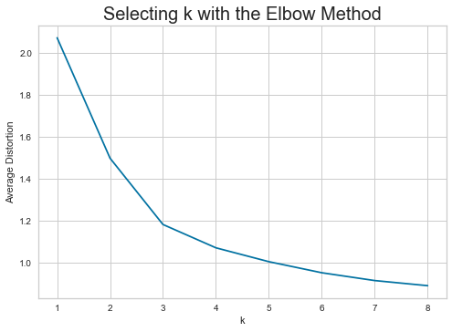

```python
clusters=range(1,9)
meanDistortions=[]

for k in clusters:
    model=KMeans(n_clusters=k)
    model.fit(subset_scaled_df)
    prediction=model.predict(subset_scaled_df)
    distortion=sum(np.min(cdist(subset_scaled_df, model.cluster_centers_, 'euclidean'), axis=1)) / subset_scaled_df.shape[0]

    meanDistortions.append(distortion)

    print('Number of Clusters:', k, '\tAverage Distortion:', distortion)

plt.plot(clusters, meanDistortions, 'bx-')
plt.xlabel('k')
plt.ylabel('Average Distortion')
plt.title('Selecting k with the Elbow Method', fontsize=20)
```

The appropriate value of k from elbow curve seems to be 4

### Lets check silhoutte score

```python
sil_score = []
cluster_list = list(range(2,10))
for n_clusters in cluster_list:
    clusterer = KMeans(n_clusters=n_clusters)
    preds = clusterer.fit_predict((subset_scaled_df))
    score = silhouette_score(subset_scaled_df, preds)
    sil_score.append(score)
    print("For n_clusters = {}, silhouette score is {})".format(n_clusters, score))
```

```
For n_clusters = 2, silhouette score is 0.4201583924929177)
For n_clusters = 3, silhouette score is 0.5169867470092899)
For n_clusters = 4, silhouette score is 0.38147048130671246)
For n_clusters = 5, silhouette score is 0.35332888701008774)
For n_clusters = 6, silhouette score is 0.2710222807106636)
For n_clusters = 7, silhouette score is 0.26703899794942365)
For n_clusters = 8, silhouette score is 0.25688385585465895)
For n_clusters = 9, silhouette score is 0.2419815883012941)
```

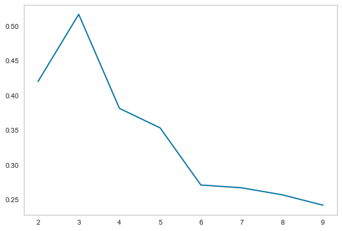

```python
plt.plot(cluster_list,sil_score)
plt.grid()
```

## Finding Optimal No.of Clusters

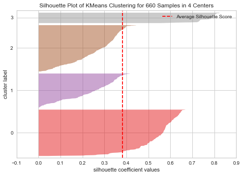

```python
visualizer = SilhouetteVisualizer(KMeans(4, random_state = 1))
visualizer.fit(subset_scaled_df)
visualizer.show()
```

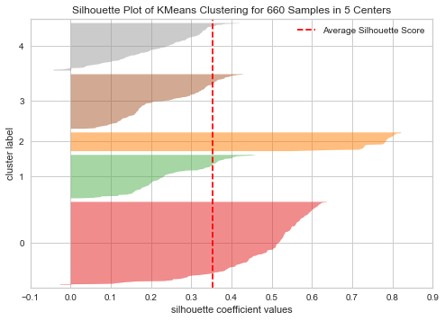

```python
visualizer = SilhouetteVisualizer(KMeans(5, random_state = 1))
visualizer.fit(subset_scaled_df)
visualizer.show()
```

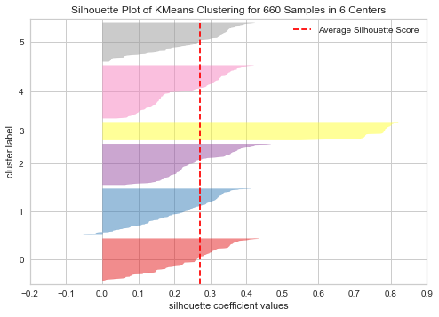

```python
visualizer = SilhouetteVisualizer(KMeans(6, random_state = 1))
visualizer.fit(subset_scaled_df)
visualizer.show()
```

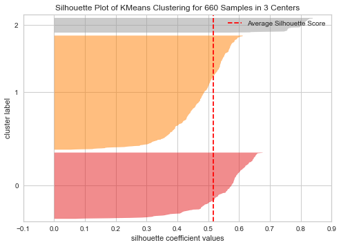

```python
visualizer = SilhouetteVisualizer(KMeans(3, random_state = 1))
visualizer.fit(subset_scaled_df)
visualizer.show()
```

### Let us take 4 as appropriate no. of clusters as silhoutte score is high enough and there is Knick at 4 in elbow curve.

```python
kmeans = KMeans(n_clusters=4, random_state=0)
kmeans.fit(subset_scaled_df)
```

```
KMeans(n_clusters=4, random_state=0)
```

```python
df1=df.copy()
```

```python
df1['K_means_segments'] = kmeans.labels_
```

### Cluster Profiling K Means

```python
cluster_profile = df1.groupby('K_means_segments').mean()
```

```python
cluster_profile['count_in_each_segment'] = df1.groupby('K_means_segments')['Avg_Credit_Limit'].count().values
```

```python
cluster_profile
```

| K_means_segments | Avg_Credit_Limit | Total_Credit_Cards | Total_visits_bank | Total_visits_online | Total_calls_made | count_in_each_segment |
| --- | --- | --- | --- | --- | --- | --- |
| 0 | 17295.964126 | 5.497758 | 3.708520 | 1.017937 | 1.941704 | 223 |
| 1 | 12197.309417 | 2.403587 | 0.928251 | 3.553812 | 6.883408 | 223 |
| 2 | 102660.000000 | 8.740000 | 0.600000 | 8.180000 | 1.080000 | 50 |
| 3 | 56036.585366 | 5.530488 | 3.182927 | 0.939024 | 2.091463 | 164 |

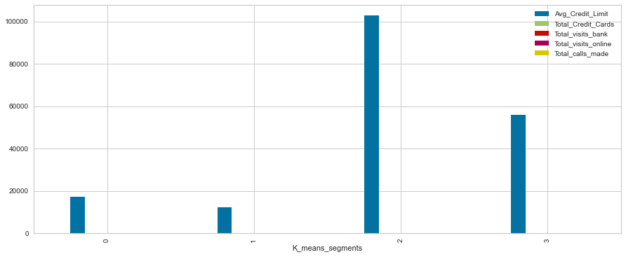

```python
df1.groupby('K_means_segments').mean().plot.bar(figsize=(15,6))
```

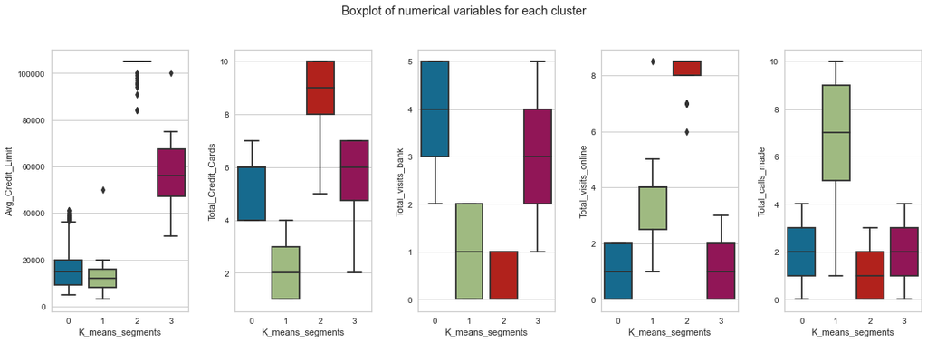

```python
fig, axes = plt.subplots(1, 5,  figsize=(16, 6))
fig.suptitle('Boxplot of numerical variables for each cluster')
counter = 0
for ii in range(5):
    sns.boxplot(ax=axes[ii],y=df1[all_col[counter]],x=df1['K_means_segments'])
    counter = counter+1

fig.tight_layout(pad=2.0)
```

## Insights-K Means

### Cluster 0

Avg_Credit_Limit less than 40,000 for majority of customers  
Total_credit_cards range from 4 to 7  
Total_visits_bank range from 2 to 5  
Total_visits_online range from 0 to 2  
Total_calls_made range from 0 to 4

# Hierarchical Clustering

### Standardize the data

```python
subset1=df.copy()
sc = StandardScaler()
subset_scaled_df=pd.DataFrame(sc.fit_transform(subset1),columns=subset1.columns)
subset_scaled_df.head()
```

|  | Avg_Credit_Limit | Total_Credit_Cards | Total_visits_bank | Total_visits_online | Total_calls_made |
| --- | --- | --- | --- | --- | --- |
| 0 | 2.398942 | -1.249225 | -0.860451 | -0.619767 | -1.251537 |
| 1 | 0.643619 | -0.787585 | -1.473731 | 2.705813 | 1.891859 |
| 2 | 0.643619 | 1.058973 | -0.860451 | 0.267054 | 0.145528 |
| 3 | -0.058511 | 0.135694 | -0.860451 | -0.619767 | 0.145528 |
| 4 | 2.398942 | 0.597334 | -1.473731 | 2.705813 | -0.203739 |

### Hierarchical Clustering with different Linkage Methods

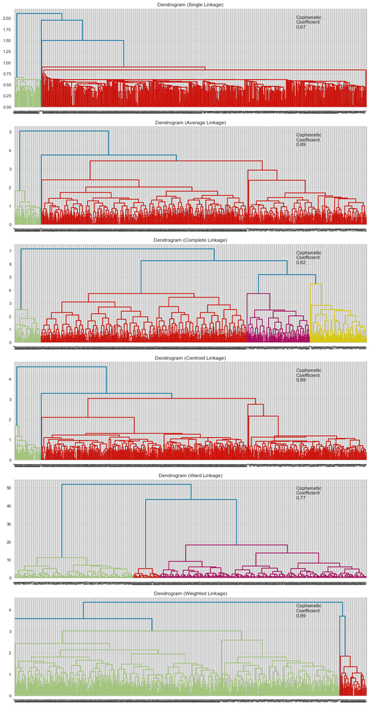

```python
methods = ['single',
           'average',
           'complete',
           'centroid',
           'ward',
          'weighted']


compare_cols = ['Linkage', 'Cophenetic Coefficient']


fig, axs = plt.subplots(len(methods), 1, figsize=(15, 30))

for i, method in enumerate(methods):

    Z = linkage(subset_scaled_df, metric='euclidean', method=method)

    dendrogram(Z, ax=axs[i]);
    axs[i].set_title(f'Dendrogram ({method.capitalize()} Linkage)')
    coph_corr, coph_dist = cophenet(Z, pdist(subset_scaled_df))
    axs[i].annotate(f'Cophenetic\nCoefficient\n{coph_corr:0.2f}',
                    (0.80, 0.80),
                    xycoords='axes fraction')
```

### Observation

Lets choose Dendrogram with Ward linkage  
4 clusters would be appropriate number of clusters for us

### Lets us create 4 clusters

```python
HCmodel = AgglomerativeClustering(n_clusters=4,affinity='euclidean', linkage='ward')
HCmodel.fit(subset_scaled_df)
subset_scaled_df['HC_Clusters'] = HCmodel.labels_
```

```python
df2=df.copy()
```

```python
df2['HC_Clusters'] = HCmodel.labels_
```

### Cluster Profiling Hierarchical Cluster

```python
cluster_profile = df2.groupby('HC_Clusters').mean()
```

```python
cluster_profile['count_in_each_segments'] = df2.groupby('HC_Clusters')['Avg_Credit_Limit'].count().values
```

```python
cluster_profile.style.highlight_max(color = 'lightgreen', axis = 0)
```

| HC_Clusters | Avg_Credit_Limit | Total_Credit_Cards | Total_visits_bank | Total_visits_online | Total_calls_made | count_in_each_segments |
| --- | --- | --- | --- | --- | --- | --- |
| 0 | 20666.666667 | 5.474510 | 3.678431 | 1.054902 | 2.054902 | 255 |
| 1 | 12197.309417 | 2.403587 | 0.928251 | 3.553812 | 6.883408 | 223 |
| 2 | 102660.000000 | 8.740000 | 0.600000 | 8.180000 | 1.080000 | 50 |
| 3 | 58916.666667 | 5.583333 | 3.113636 | 0.848485 | 1.909091 | 132 |

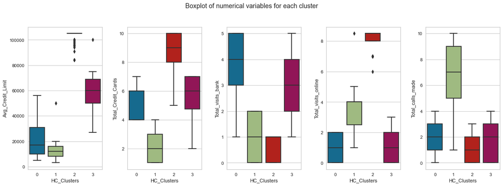

```python
fig, axes = plt.subplots(1, 5,  figsize=(16, 6))
fig.suptitle('Boxplot of numerical variables for each cluster')
counter = 0
for ii in range(5):
    sns.boxplot(ax=axes[ii],y=df2[all_col[counter]],x=df2['HC_Clusters'])
    counter = counter+1

fig.tight_layout(pad=2.0)
```

### Insights- Hierarchical Clusters

#### Cluster 0

Avg_Credit_Limit is up to 5000 to ~58000 for customers in this group  
Total_credit_cards range from 4 to 7  
Total_visits_bank range from 1 to 5  
Total_visits_online range from 0 to 2  
Total_calls_made range from 0 to 4

#### Cluster 1

Avg_Credit_Limit is up to 20000 for customers in this group  
Total_credit_cards range from 1 to 4  
Total_visits_bank range from 0 to 2  
Total_visits_online range from 1 to 5  
Total_calls_made range from 1 to 10

#### Cluster 3

Avg_Credit_Limit range from about 25000 to 78000  
Total_credit_cards range from 2 to 7  
Total_visits_bank range from 1 to 5  
Total_visits_online range from 0 to 3 visits  
Total_calls_made range from 0 to 4

### Cluster Comparison-K Means & Hierarchical Clusters

We have chosen 4 clusters for both K-Means and Hierarchical clustering .

# Conclusion & Business Recommendations

#### Group 0: The Average Spending customers

These group of customers have median avg_credit_limit and most of their interactions with the bank are inperson with very few online visits and low number of calls made to the bank.The bank can target to make the customers use more of the online services and reduce inperson visits by providing better customer service

#### Group 1: The Low Spending Customers

These group of customers have low avg_credit_limit and hold the least number of credit cards. Their interactions with the bank are mostly through online and calls made to the bank.The bank can target the customers to increase their average spending by providing more offers and options to chose for better credit cards that suite their needs.

#### Group 2: The High Spending Customers

These group of customers have high avg_credit_limit and hold the highest number of credit cards. Their interactions with the bank are mostly online.The bank should continue to provide good services to these group of customers

#### Group 3 The Above Avg Spending Customers

The group of customers have above average credit line .Their interactions with the bank are mostly in person.The Bank should provide more options to maintain increase their credit line and better customer service.